# MapOSR Replication Project

Replication of Figure 2 — Studies by Open Science Subfield (2000–2020)

Abhishek Verma

## What this presentation does

**Replication target:** Figure 2 (stacked bars: number of studies per year by Open Science subfield).

**Data used:** the provided MapOSR coded dataset (`mapOSR_data_V5_9_3_220419_coded_clean.csv`).  
The replication is feasible because the dataset already contains the two key variables needed:

- **`Publication Year`** = year of publication
- **`Action`** = Open Science subfield(s) (sometimes multiple per record, stored as a list-like string)

## Folder structure (so this runs on your machine)

Expected project folders:

- `data/` → contains the CSV
- `outputs/` → will store the generated figure + intermediate CSVs

If `outputs/` does not exist, this script will create it.

```r
# Create outputs folder if it doesn't exist
if (!dir.exists("outputs")) dir.create("outputs", recursive = TRUE)
```

## Step 1 — Load libraries

We use **tidyverse** for data import, cleaning, and plotting.

```r
library(tidyverse)
library(here)
```

## Step 2 — Load the dataset

```r
maposr <- read_csv(here("data/mapOSR_data_V5_9_3_220419_coded_clean.csv"))
```

Quick sanity checks:

```r
#dim(maposr)
#glimpse(maposr)
```

## Step 3 — Confirm the key variables exist

This replication depends on `Publication Year` and `Action`.

```r
summary(maposr$`Publication Year`)
```

```
   Min. 1st Qu.  Median    Mean 3rd Qu.    Max.    NA's
   2001    2014    2017    2016    2019    2021      10
```

```r
table(is.na(maposr$`Publication Year`))
```

```
FALSE  TRUE
  685    10
```

```r
table(is.na(maposr$Action))
```

```
FALSE
  695
```

## Step 4 — Why cleaning is needed for `Action`

In the dataset, `Action` can contain multiple subfields per study (example idea: `"['openaccess', 'opendata']"`).  
To replicate Figure 2, we must:

1. remove the bracket/quote formatting
2. split multiple subfields into separate rows (one row = one subfield assignment)

## Step 5 — Clean and reshape the data

```r
clean_data <- maposr %>%
  select(`Publication Year`, Action) %>%
  filter(!is.na(`Publication Year`), !is.na(Action)) %>%
  mutate(Action = str_remove_all(Action, "\\[|\\]|'")) %>%   # remove [ ] and '
  separate_rows(Action, sep = ", ") %>%                     # split multi-label cells
  mutate(Action = str_trim(Action))                          # trim spaces

head(clean_data)
```

```
# A tibble: 6 × 2
  `Publication Year` Action
               <dbl> <chr>
1               2015 openaccess
2               2013 openaccess
3               2013 openpolicies
4               2018 openaccess
5               2020 openaccess
6               2019 openaccess
```

Stacking order is controlled by the **factor levels** of `Action`.

```r
clean_data$Action <- factor(
  clean_data$Action,
  levels = c(
    "openaccess",
    "openpolicies",
    "openscience",
    "openmethod",
    "opendata",
    "openevaluation",
    "opentools",
    "openeducation",
    "opensoftware",
    "openparticipation"
  )
)
```

## Step 7 — Count publications per year × subfield (2000–2020)

```r
fig2_counts <- clean_data %>%
  filter(`Publication Year` >= 2000, `Publication Year` <= 2020) %>%
  group_by(`Publication Year`, Action) %>%
  summarise(n = n(), .groups = "drop")

head(fig2_counts)
```

```
# A tibble: 6 × 3
  `Publication Year` Action         n
               <dbl> <fct>      <int>
1               2001 openaccess     1
2               2003 openaccess     2
3               2004 openaccess     1
4               2005 openaccess     1
5               2006 openaccess     6
6               2007 openaccess    13
```

```r
paper_colors <- c(
  openaccess        = "#1F77B4",
  openpolicies      = "#FF7F0E",
  openscience       = "#9467BD",
  openmethod        = "#E377C2",
  opendata          = "#2CA02C",
  openevaluation    = "#BCBD22",
  opentools         = "#FFD700",
  openeducation     = "#17BECF",
  opensoftware      = "#8C564B",
  openparticipation = "#D62728"
)
```

| subfield | color | hex |
| --- | --- | --- |
| openaccess |  | #1F77B4 |
| openpolicies |  | #FF7F0E |
| openscience |  | #9467BD |
| openmethod |  | #E377C2 |
| opendata |  | #2CA02C |
| openevaluation |  | #BCBD22 |
| opentools |  | #FFD700 |
| openeducation |  | #17BECF |
| opensoftware |  | #8C564B |
| openparticipation |  | #D62728 |

## Step 9 — Plot Figure 2 (replication)

```r
fig2_plot <- ggplot(fig2_counts,
                    aes(x = `Publication Year`, y = n, fill = Action)) +
  geom_col(color = "black", size = 0.2) +
  scale_fill_manual(values = paper_colors) +
  scale_x_continuous(breaks = seq(2000, 2020, 5), limits = c(2000, 2020)) +
  scale_y_continuous(breaks = seq(0, 140, 20), limits = c(0, 160)) +
  theme_minimal(base_size = 13) +
  theme(
    panel.grid = element_blank(),
    axis.line = element_line(colour = "black"),
    axis.ticks = element_line(colour = "black"),
    legend.title = element_blank(),
    legend.position = c(0.18, 0.60),
    legend.background = element_rect(fill = "white", color = "black")
  ) +
  labs(
    x = "year of publication",
    y = "number of publications",
    caption = "Figure 2. Overview over the number of studies by Open Science subfield published between 2000 and 2020."
  )

fig2_plot
```

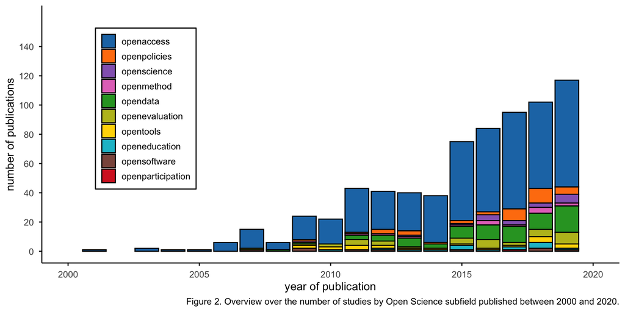

## Step 10 — Save outputs (for your report + slides)

```r
ggsave("outputs/figure2_replication.png", fig2_plot, width = 8, height = 4, dpi = 300)
ggsave("outputs/figure2_replication.pdf", fig2_plot, width = 10, height = 4)

write_csv(clean_data,  "outputs/figure2_clean_data.csv")
write_csv(fig2_counts, "outputs/figure2_counts.csv")
```

## Comparison: Original vs. Replication

### Original Paper

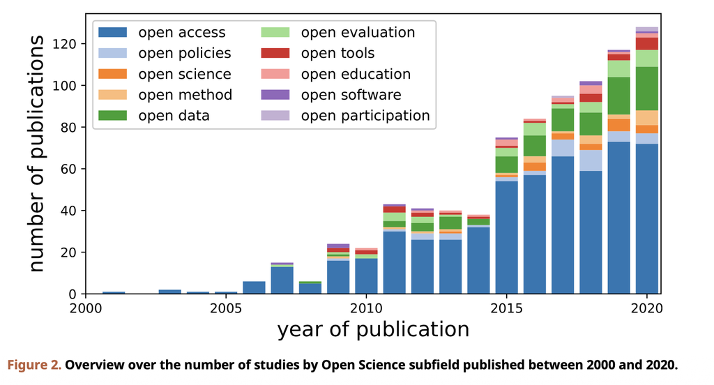

### Our Replication

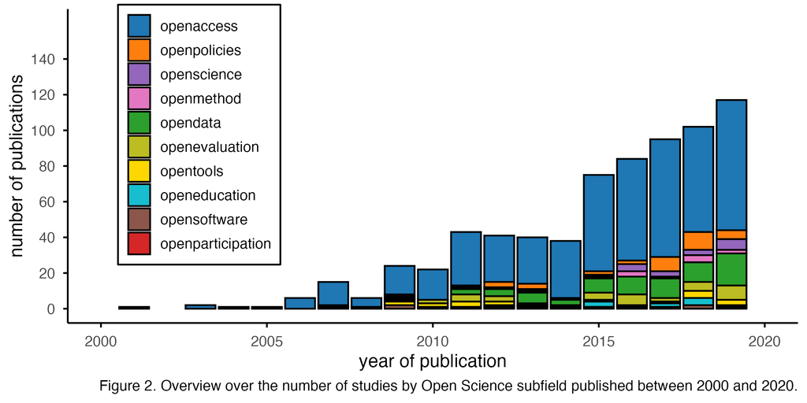

## Replication Notes)

**Deliverables produced by the workflow:** final figure (`.png` + `.pdf`) and the intermediate cleaned/count tables in `outputs/`.

## Appendix — Original scripts provided

These two scripts correspond to the same steps shown in this presentation:

- Data loading script: `01_load_data.R`
- Cleaning + Figure 2 replication script: `Figure2_clean_data.R`